# Riemann Tensor for a Sphere and Schwarzschild Christoffel Symbols

### **NOTES ON STATISTICS, PROBABILITY and MATHEMATICS**

### Components of the Riemann Curvature Tensor for a Sphere:

This page is essentially an annotated transcription of [this post](https://ekamperi.github.io/mathematics/2019/10/29/riemann-curvature-tensor.html) by Stathis Kamperis, including Mathematica code, also reflected in [here](https://www.wolframcloud.com/obj/antoniparellada/Published/Riemann%20curvature%20tensor%20sphere.nb).

This is the derivation of the [Christoffel symbols for spherical coordinates](https://physicspages.com/pdf/Relativity/Christoffel%20symbols%20defined%20for%20a%20sphere.pdf).

Given the metric tensor of the sphere

$$\begin{pmatrix}
g_{\theta \theta} & g_{\theta \phi} \\
g_{\phi \theta} & g_{\phi \phi}
\end{pmatrix}=
\begin{pmatrix}
R^2 & 0 \\
0 & R^2\sin^2\theta
\end{pmatrix}$$

with the inverse

$$\begin{pmatrix}
g^{\theta \theta} & g^{\theta \phi} \\
g^{\phi \theta} & g^{\phi \phi}
\end{pmatrix}=
\begin{pmatrix}
\frac 1{R^2} & 0 \\
0 & \frac{\csc^2\theta}{R^2}
\end{pmatrix}$$

and the Christoffel symbols

$$\Gamma_{\mu\nu}^\theta =
\left(
\begin{array}{cc}
0 & 0 \\
0 & -\sin \theta \cos \theta \\
\end{array}
\right)\qquad
\Gamma_{\mu\nu}^\phi =
\left(
\begin{array}{cc}
0 & \cot \theta \\
\cot \theta & 0 \\
\end{array}
\right)$$

calculated via

$$\Gamma_{\mu\nu}^\lambda =
\frac{1}{2}g^{\lambda\sigma} \left(
\frac{\partial g_{\sigma\nu}}{\partial x^\mu} +
\frac{\partial g_{\sigma\mu}}{\partial x^\nu} -
\frac{\partial g_{\mu\nu}}{\partial x^\sigma}\right)=
\frac{1}{2}g^{\lambda\sigma} \left( \partial_\mu g_{\sigma\nu} +
\partial_\nu g_{\sigma\mu} - \partial_\sigma
g_{\mu\nu}\right)$$

This teddy bear of an equation is directly derived from the fact that we are using the [Levy-Civita connection](https://en.wikipedia.org/wiki/Levi-Civita_connection), which is torsion-free, and metric compatible. What follows is explained in [here](https://youtu.be/cEEahoUUGyc?si=JS7eyujdnU0BWN6L):

Torsion-free implies that the Lie bracket of the basis vectors is zero because the vectors are partial derivative operators, which are the same in both directions. Hence,

$$[\partial_i, \partial_j]= \partial_i
\partial_j - \partial_j\partial_i = \frac{\partial^2}{\partial u^i
\partial u^j} - \frac{\partial^2}{\partial u^j \partial u^i} =
0$$
But then the difference in covariant derivatives

$$\nabla_{\vec w} \vec v - \nabla_{\vec v}
\vec w=[\vec v, \vec w]=0$$

And hence,

$$\nabla_{\vec e_i} \vec e_j =\nabla_{\vec
e_j} \vec e_i$$

and since $\nabla_{\vec e_i} \vec e_j= \Gamma^k_{~ij} \vec e_k$ and $\nabla_{\vec e_j} \vec e_i= \Gamma^k_{~ji} \vec e_k$,

$$\Gamma^k_{~ij} \vec e_k = \Gamma^k_{~ji}
\vec e_k$$

In other words we can swap the lower indices of the Christoffel symbols.

On the other hand, the metric compatibility property implies that

$$\nabla_{\vec w}(\vec v \cdot\vec u)=
\nabla_{\vec w} \cdot \vec u + \vec v \cdot (\nabla_{\vec w}\cdot \vec
u)$$

which means that the dot product stays the same when vectors are transported, and, therefore, also angles and lengths (just consider a vector with itself). This is true since in parallel transport the covariant derivative is zero $\nabla_{\vec w} \vec v = \nabla_{\vec w}\vec u=\vec 0,$ the equation above is simplified to $_{w}(v u)=$ constant dot product. Also, since the dot product is a scalar, $\nabla_{\partial_i}(\vec v \cdot \vec u)=\partial_i(\vec v \cdot \vec u)=0.$

Looking at the basis vectors,

$$\begin{align}
\nabla_{\vec e_k}(\vec e_i \cdot \vec e_j) &= (\nabla_{\vec e_k}
\vec e_i ) \cdot \vec e_j + \vec e_i \cdot (\nabla_{\vec e_k} \vec e_j)
\\
\partial_k(\vec e_i \cdot \vec e_j) &=(\Gamma^l_{~ik} \vec e_l)
\cdot \vec e_j + \vec e_i\cdot(\Gamma^l_{~jk}\vec e_l)\\
\partial_k(g_{ij}) &= \Gamma^l_{~ik}g_{jl} + \Gamma^l_{~jk}g_{il}
\end{align}$$

Following this equality we can permute the indices as in:

$$\begin{align}
\partial_k(g_{ij}) &= \Gamma^l_{~ik}g_{jl} + \Gamma^l_{~jk}g_{il}\\
\partial_j(g_{ki}) &= \Gamma^l_{~kj}g_{il} + \Gamma^l_{~ij}g_{kl}\\
\partial_i(g_{jk}) &= \Gamma^l_{~ji}g_{kl} + \Gamma^l_{~ki}g_{jl}
\end{align}$$

Taking into account the fact that swapping the lower indices of the Christoffel symbols does not alter them, we can perform the following operation

$$\partial_k g_{ij}+ \partial_j g_{ki}-
\partial_i g_{jk}$$
and see a lot of cancellations, resulting in

$$\partial_k g_{ij}+ \partial_j g_{ki}-
\partial_i g_{jk} = 2\Gamma^l_{jk}g_{il}$$
or

$$\Gamma^m{}_{jk}=\frac 1 2
g^{\color{red}im}(\partial_k g_{\color{red}ij}+ \partial_j
g_{k\color{red}i }- \partial_\color{red}i g_{jk})$$

Notice the implied summation for each Christoffel symbol in the dummy index $i$ (sometimes labelled $\sigma$):

$$\Gamma^\lambda{}_{\mu\nu}= \frac 1 2
g^{\color{red}\sigma\lambda}(\partial_\nu \, g_{\color{red}\sigma \mu} +
\partial_\mu \, g_{\nu\color{red}\sigma } -
\partial_\color{red}\sigma\,g_{\mu\nu})$$

$\mu$ is the basis vector being parallel transported

$\nu$ is the direction in which the basis vector is being transported.

$\lambda$ indicates the component of the transported vector in the new basis.

$\sigma$ is summed over and it is there to capture the contributions from different directions in the coordinate space.

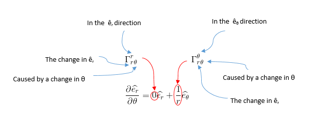

So for instance, in the sphere, and for $\lambda=1=\theta, \mu=2=\phi,\nu=2=\phi$

$$\begin{align}\Gamma^{\theta}_{\mu\nu}=\Gamma^{\theta}_{\phi\phi}=\Gamma^1{}_{22}&=\frac
1 2\sum_{σ=1}^n g^{λσ} (∂_μ g_{σν} + ∂_ν g_{σμ} - ∂_σ g_{μν})\\
&=\frac 1 2 \left(g^{λ\theta} \left( ∂_μ g_{\theta ν} + ∂_ν
g_{\theta μ} - ∂_\theta g_{μν}\right) + g^{λ\phi} \left( ∂_μ g_{\phi ν}
+ ∂_ν g_{\phi μ} - ∂_\phi g_{μν}\right)\right)\\
&=\frac 1 2 \left(g^{\theta\theta} \left( ∂_\phi g_{\theta \phi} +
∂_\phi g_{\theta \phi} - ∂_\theta g_{\phi\phi}\right) + g^{\theta\phi}
\left( ∂_\phi g_{\phi \phi} + ∂_\phi g_{\phi \phi} - ∂_\phi
g_{\phi\phi}\right)\right)\\
&=\frac 1 2 \left(\frac{1}{r^2}(0+0-2r^2\sin\theta\cos\theta) +
0(0+0-0) \right)\\
&=-\sin\theta\cos\theta
\end{align}$$

For $\lambda=2=\phi, \mu=1=\theta,\nu=2=\phi$

$$\begin{align}\Gamma^{\phi}_{\mu\nu}=\Gamma^{\phi}_{\theta\phi}=\Gamma^2{}_{12}&=\frac
1 2\sum_{σ=1}^n g^{λσ} (∂_μ g_{σν} + ∂_ν g_{σμ} - ∂_σ g_{μν})\\
&=\frac 1 2 \left(g^{λ\theta} \left( ∂_μ g_{\theta ν} + ∂_ν
g_{\theta μ} - ∂_\theta g_{μν}\right) + g^{λ\phi} \left( ∂_μ g_{\phi ν}
+ ∂_ν g_{\phi μ} - ∂_\phi g_{μν}\right)\right)\\
&=\frac 1 2 \left(g^{\phi\theta} \left( ∂_\theta g_{\theta \phi} +
∂_\phi g_{\theta \theta} - ∂_\theta g_{\theta\phi}\right) + g^{\phi\phi}
\left( ∂_\theta g_{\phi \phi} + ∂_\phi g_{\phi \theta} - ∂_\phi
g_{\theta\phi}\right)\right)\\
&=\frac 1 2
\left( \frac{\csc^2\theta}{R^2}\left(2R^2\sin\theta\cos\theta+0-0\right)
\right)\\
&=\cot\theta
\end{align}$$

```
ChristoffelSymbol[111]=0
Indices:θ/φ=1,μ=1,ν=1

ChristoffelSymbol[112]=0
Indices:θ/φ=1,μ=1,ν=2

ChristoffelSymbol[121]=0
Indices:θ/φ=1,μ=2,ν=1

ChristoffelSymbol[122]=-Cos[θ]Sin[θ]
Indices:θ/φ=1,μ=2,ν=2

ChristoffelSymbol[211]=0
Indices:θ/φ=2,μ=1,ν=1

ChristoffelSymbol[212]=Cot[θ]
Indices:θ/φ=2,μ=1,ν=2

ChristoffelSymbol[221]=Cot[θ]
Indices:θ/φ=2,μ=2,ν=1

ChristoffelSymbol[222]=0
Indices:θ/φ=2,μ=2,ν=2
```

the Riemann curvature tensor components can be calculated as

$$R^i_{~rkj}=
\frac{\partial\Gamma^i_{~jr}}{\partial u^k}
-\frac{\partial\Gamma^i_{~kr}}{\partial u^j}
+\Gamma^i_{~ks}\Gamma^s_{~jr}
-\Gamma^i_{~js}\Gamma^s_{~kr}$$

Notice the implied summation, so that

$$R^\rho{}_{\sigma\mu\nu}=
\partial_\mu\Gamma^\rho{}_{\nu\sigma}
-\partial_\nu\Gamma^\rho_{\mu\sigma}
+\Gamma^\rho{}_{\mu\lambda}\Gamma^\lambda{}_{~\nu\sigma}
-\Gamma^\rho{}_{\nu\lambda}\Gamma^\lambda{}_{\mu\sigma}\\=\partial_\mu\Gamma^\rho{}_{\nu\sigma}
-\partial_\nu\Gamma^\rho_{\mu\sigma} +\sum_{\lambda=1}^2
\left(\Gamma^\rho{}_{\mu\lambda}\Gamma^\lambda{}_{~\nu\sigma}
-\Gamma^\rho{}_{\nu\lambda}\Gamma^\lambda{}_{\mu\sigma}
\right)$$

Example:

$$R^\theta{}_{\phi\theta\phi}=\partial_\theta\Gamma^{\theta}{}_{\phi\phi}-\partial_\phi
\Gamma^\theta{}_{\theta\phi}+\sum_{\lambda=1}^2\left(\Gamma^\theta{}_{\theta\lambda}\Gamma^\lambda_{\phi\phi}
-
\Gamma^\theta{}_{\phi\lambda}\Gamma^\lambda_{\theta\phi}\right)=\sin^2\theta$$

The rest of the Riemann tensor coefficients are:

$$R = \left(
\begin{array}{cc}
\left(
\begin{array}{cc}
0 & 0 \\
0 & 0 \\
\end{array}
\right) & \left(
\begin{array}{cc}
0 & \sin^2 \theta \\
-\sin^2 \theta & 0 \\
\end{array}
\right) \\
\left(
\begin{array}{cc}
0 & -1 \\
1 & 0 \\
\end{array}
\right) & \left(
\begin{array}{cc}
0 & 0 \\
0 & 0 \\
\end{array}
\right) \\
\end{array}
\right)$$

which corresponds to

$$R =\left(
\begin{array}{cc}
\left(
\begin{array}{cc}
R^\theta{}_{\theta\theta\theta} & R^\theta{}_{\theta\theta\phi} \\
R^\theta{}_{\theta\phi\theta} & R^\theta{}_{\theta\phi\phi} \\
\end{array}
\right) & \left(
\begin{array}{cc}
R^\theta{}_{\phi\theta\theta} & \ R^\theta{}_{\phi\theta\phi} \\
R^\theta{}_{\phi\phi\theta} & R^\theta{}_{\phi\phi\phi} \\
\end{array}
\right) \\
\left(
\begin{array}{cc}
R^\phi{}_{\theta\theta\theta} & R^\phi{}_{\theta\theta\phi}\\
R^\phi{}_{\theta\phi\theta} & R^\phi{}_{\theta\phi\phi} \\
\end{array}
\right) & \left(
\begin{array}{cc}
R^\phi{}_{\phi\theta\theta} & R^\phi{}_{\phi\theta\phi}\\
R^\phi{}_{\phi\phi\theta}& R^\phi{}_{\phi\phi\phi} \\
\end{array}
\right) \\
\end{array}
\right)$$

### Christoffel symbols for the Schwarzschild metric:

References online [here](https://physics.stackexchange.com/a/733752/150551) and [here](https://sites.math.washington.edu/~morrow/336_20/papers17/carson.pdf), and the code for the Riemann curvature tensor, the Ricci tensor and the curvature is [here](https://www.wolframcloud.com/obj/3b3b895e-406e-4e72-808b-04b99e9bd9e6).

[This post](https://mathematica.stackexchange.com/a/8908/39484) contains the code of the main functions.

The metric tensor is

$$g_{mn} =
\begin{pmatrix}
-(1-2M/r) & 0 & 0 & 0 \\
0 & (1-2M/r)^{-1} & 0 & 0 \\
0 & 0 & r^2 & 0 \\
0 & 0 & 0 & r^2\sin^2{\theta}
\end{pmatrix}$$

The Christoffel symbols are calculated as

[output not shown]

The following are the unique values:

$$\begin{equation}
\begin{matrix}
\Gamma^r_{tt}=\dfrac{M(r-2M)}{r^3}\,\text{,} & ~ &
\Gamma^r_{rr}=-\dfrac{M}{r(r-2M)}\,\text{,} & ~ &
\Gamma^r_{\theta \theta}=-(r-2M)\,\text{,}\\
~ & ~ & ~ & ~ & ~\\
\Gamma^r_{\phi \phi}=-(r-2M)\sin^2{\theta}\,\text{,} & ~ &
\Gamma^t_{rt} = \dfrac{M}{r(r-2M)}\,\text{,} & ~ &
\Gamma^\theta_{r\theta}=\dfrac{1}{r}\,\text{,}\\
~ & ~ & ~ & ~ & ~\\
\Gamma^\theta_{\phi\phi}=-\sin{\theta}\cos{\theta}\,\text{,} & ~
& \Gamma^\phi_{r\phi}=\dfrac{1}{r}\,\text{,} & ~ &
\Gamma^\phi_{\theta\phi} =
\dfrac{\cos{\theta}}{\sin{\theta}}\,\text{.}\\
~ & ~ &
\end{matrix}
\end{equation}$$

[Home Page](http://rinterested.github.io/statistics/index.html)

**NOTE: These are tentative notes on different topics for personal use - expect mistakes and misunderstandings.**